# DIABLO prepp data

Published

30 Mar 2026

## Overview:

#### DIABLO Multi-Omics Integration

1. **Load already QC and normalized data**  
   Clean, normalize, and scale each omics dataset independently.
2. **Select taxa level and combine X**  
   Use PLS-DA to confirm that class separation exists before applying sparsity.
3. **Identify sample sets**  
   Identify the optimal number of components (`ncomp`) and variables to select per component (`keepX`) via cross-validation.
4. **Select response variable**  
   Build the sPLS-DA model using the tuned parameters.
5. **Specify design matrix**  
   Evaluate classification accuracy, balanced error rate (BER), and stability of selected variables.
6. **Model**  
   Retrieve the most discriminant variables identified by the sPLS-DA model.
7. **Visualize models**  
   Use the selected features as input for integration frameworks such as **DIABLO** (`block.splsda()`).

## parameter tuning

There are several variables that wee kan tweak in order to optimise our integration model these include - weights - number of blocks - species or strain level of MG - number of features to select for tuning

I want to test a couple of combinations to see if there are any signifcant changes

## 1. Load already QC and normalized data

```r
##################
# LOAD LIBRARIES #
##################
library(tidyverse)
library(mixOmics)
library(readxl)
library(cowplot)
library(RColorBrewer)
library(scales)

library(VennDiagram)
library(gridExtra)
library(ComplexHeatmap)
library(circlize)

library(tidygraph)
library(igraph)
library(ggraph)
select <- dplyr::select
map <- purrr::map

# setwd("/Users/vilkal/work/Brolidens_work/Projects/Candida-omics/src")
```

```r
# pal <- c("#ffa998", "#f588af", "#902267") # #e05e85
# feat <- c("#bdd3c5", "#48919d", "#3d4b6eff") # "#1f2e55", "#c6cdf7"
# pal <- c("#d18ac8", "#3db8ac", "#8861d2", "#6095d7", "#755fa3", "#c44999")
feat <- c("#e39ddaff", "#6dded3ff", "#a68cd5ff") #,"#6095d7","#755fa3","#c44999")

# pal <- c("#9e8dec", "#902267", "#cc93cf", "#a5c97b", "#de9548", "#63d3b4") #"#abcb4b"

pal <- list(
  CST = c(
    "I" = "#148F77",
    "II" = "#6d9f06",
    "III" = "#A3E4D7",
    "IV-B" = "#E794C1",
    "IV-C" = "#b5cb8c",
    "V" = "#43BA8F"
  ),
  subCST = c(
    "#a5c97b",
    "#cc93cf",
    "#de9548",
    "#63d3b4",
    "#9e8dec",
    "#902267",
    '#FB5273',
    "#91c5de"
  ),
  RVVC = c("#EAEAEA", "#fd814e"),
  BV = c("#EAEAEA", "#fd814e"),
  NAC = c("#EAEAEA", "#fd814e"),
  ST = c("#EAEAEA", "#fd814e"),
  missing_page = c("#EAEAEA", "#fd814e"),
  Clin = c("#a5c97b", "#cc93cf", "#de9548", "#63d3b4", "#9e8dec", "#902267"),
  Clin_gr = c("#ffa998", '#FB5273', "#902267"),
  RVVC_AS = c("#ffa998", '#FB5273', "#902267"),
  RVVC_pos = c(
    "#A6CEE3",
    "#1F78B4",
    #"#EAEAEA",
    #"gray",
    "#e490c4ff",
    "#c12d88ff"
  ), # "#FB9A99", "#E31A1C", "#B2DF8A", "#609c5bff", "#FDBF6F", "#FF7F00",, "#CAB2D6", "#6a3d9a" "#e490c4ff", "#c12d88ff"
  trx_louvain_7 = c(
    "#de9548",
    "#cc93cf",
    "#a5c97b",
    "#9e8dec",
    "#902267",
    "#63d3b4",
    '#FB5273'
  ),
  metab_louvain = c(
    "#cc93cf",
    "#a5c97b",
    "#de9548",
    "#902267",
    "#9e8dec",
    "#63d3b4"
    #'#FB5273'
  ),
  microb_louvain = c(
    "#cc93cf",
    "#de9548",
    "#a5c97b",
    "#9e8dec",
    "#902267",
    "#63d3b4",
    '#FB5273'
  ),
  fun_louvain = c(
    "#a5c97b",
    "#cc93cf",
    "#de9548",
    "#63d3b4",
    "#9e8dec",
    "#902267",
    '#FB5273'
    #"#984EA3"
    #"#B3CDE3"
  ),
  integ_louvain = c(
    "#a5c97b",
    "#cc93cf",
    "#de9548",
    "#63d3b4",
    "#9e8dec",
    "#902267",
    '#FB5273',
    "#984EA3"
    #"#B3CDE3"
  ),
  "Wet_smear:_clue_cells_(y/n)" = c("#2266ac", "#91c5de"),
  hyphae = c("#f26386", "#fd814e", "#a4d984", "#fbbc52"),
  pos = c("#91c5de", "#2266ac"),
  "Clinical_score_(0-5)" = brewer.pal(6, name = "Reds")
)
```

```r
data_path <- "/Users/vilkal/work/Brolidens_work/Projects/Candida-omics/Tidy_data/Metagenomics/Metageonome_all_vagswab_metaphlan.csv"
# meta_path <- "/Users/vilkal/Downloads/Metadata_svamp.xlsx"

#############
# LOAD DATA #
#############
TRX_path <- "../Results/MixOmic/Transcriptomics_batch_filt.csv"
MG_path <- "../Results/MixOmic/Metageonome_vagswab_CLR_transformed.RDS"
MB_path <- "../Results/MixOmic/Metabolom_Normalized.csv"
FM_path <- "../Tidy_data/Metagenomics/Functional_annotation_CLR_filtered.RDS"

# expression data
TRX_batch <- read.csv(TRX_path, row.names = 1)
MG_matrix <- readRDS(MG_path)
MB_matrix <- read.csv(MB_path, row.names = 1)
FM_matrix <- readRDS(FM_path)

top_hvg <- read_csv("../Results/Tissue_QC/HVG.csv")

#############
# LOAD META #
#############
Clin_path <- "/Users/vilkal/work/Brolidens_work/Projects/Candida-omics/data/Metadata_svamp_FINAL.xlsx"
comb_meta_path <- "../Results/Combined_gr_meta_data.csv"

# meta data
Clin_data <- read_xlsx(Clin_path, sheet = "Metadata", na = "na")
meta <- read_csv(comb_meta_path) %>%
  rename(svamp_ID = "sample") %>%
  mutate(across(contains("louvain"), ~ factor(.x))) %>%
  mutate(across(2:25, ~ factor(.x)))

m <- read_csv("../Results/Sample_omic_table.csv")
```

## 2. Preparing multi-omics matrices

### Steps for preparing multi-omics matrices (TR, MG, MB)

1. **Remove unwanted taxa**
   - For MG data, drop columns whose taxa names match a set of regular expressions  
     (e.g., remove Candida/fungi using regex patterns).
2. **Select a taxonomic level for MG**
   - Choose one level from the `clr_data` list (species, genus, family, etc.).
3. **Orient all matrices so that samples are rows**
   - TR and MB may need to be transposed and converted into matrices.
   - MG is already sample × feature.
4. **Compute the intersection of shared samples**
   - Extract row names from TR, MG, and MB and identify samples common to all layers.
5. **Subset all matrices to include only overlapping samples**
   - Ensures all omics blocks have the same sample set and can be correlated.
6. **Return the cleaned and aligned omics list**
   - The final list contains `X$TR`, `X$MG`, and `X$MB`, all with identical sample ordering.

```r
# ---- 2. Remove unwanted taxa (candida) from MG ----
# k__Eukaryota|p__Ascomycota|c__Saccharomycetes|o__Saccharomycetales|f__Debaryomycetaceae|g__Candida|s__Candida_albicans
reg <- c(
  "kingdom" = "",
  "phylum" = "Ascomycota",
  "class" = "Saccharomycetes",
  "order" = "Saccharomycetales",
  "family" = "Debaryomycetaceae",
  "genus" = "Candida",
  "species" = "Candida_albicans|Candida_parapsilosis|Candida_dubliniensis",
  "strain" = "Candida_albicans EUK5476|Candida_parapsilosis EUK5480|Candida_dubliniensis EUK42374|Candida_glabrata EUK5478"
)

prep_multi_omics <- function(
  taxa_level = "species",
  remove_regex_list = reg
) {
  if (!is.null(remove_regex_list)) {
    MG_matrix <- MG_matrix %>%
      mutate(across(
        clr_data,
        ~ imap(
          .,
          ~ .x[, !grepl(remove_regex_list[[.y]], colnames(.x)), drop = FALSE]
        )
      ))
  }
  # ---- 1. select taxa level and remove long strain id, replace with int
  MG_matrix <- MG_matrix[["clr_data"]][[taxa_level]]
  new_names <- sub("\\s+\\S+$", "", colnames(MG_matrix)) # remove strain id
  new_names <- make.unique(new_names, sep = " ") # Make names unique
  colnames(MG_matrix) <- new_names # Assign new names

  # ---- 3. select 5000 most higly variable genes
  TRX_HVG <- TRX_batch[top_hvg$gene[1:5000], ]

  # ---- 4. Ensure correct orientation (samples = rows) ----
  views <- list(
    Transcriptomics = as.matrix(t(TRX_HVG)),
    Metabolomics = as.matrix(t(MB_matrix)),
    Metagenomics = unclass(MG_matrix),
    Functional = unclass(t(FM_matrix$path_lvl))
  )

  # ---- 5. filter to include selected samples for MOFA
  m_ <- m %>%
    filter(sample %in% .$sample[m$at_least_two & m$all_BL])

  X <- views %>%
    imap(., ~ .x[m_$sample[m_[[.y]]], ])

  # ---- 6. Subset each matrix to baseline only and overlapping samples ----
  ids <<- map(X, rownames)
  ids_uniq <<- Reduce(intersect, map(X, rownames))

  X <- X %>%
    map(~ .x[ids_uniq, , drop = FALSE]) %>%
    set_names(., c("TR", "MB", "MG", "FU"))
  return(X)
}

X <- c("species", "strain") %>%
  set_names(.) %>%
  map(., ~ prep_multi_omics(taxa_level = .x))
```

```r
gr <- meta %>%
  filter(svamp_ID %in% ids_uniq)

# group distribution
vars <- c(
  "Clinical_score_(0-5)",
  "Clin_gr",
  "RVVC",
  "hyphae",
  "RVVC_pos",
  "BV"
) %>%
  set_names()
map(vars, ~ table(gr[[.x]]))
```

```
$`Clinical_score_(0-5)`

 0  1  2  3  4  5
42  6  9  5  5  3

$Clin_gr

  0 1-3 4-5
 42  20   8

$RVVC

Control    RVVC
     39      31

$hyphae

  Control Control_H      RVVC    RVVC_H
       36         3        15        16

$RVVC_pos

Control_neg Control_pos    RVVC_neg    RVVC_pos
         29          10           8          23

$BV

 no yes
 66   4
```

```r
# specify Y
Y <- c("Clinical_score_(0-5)", "Clin_gr", "RVVC_pos", "pos") %>%
  set_names() %>%
  #set_names(., c("Clin", "Clin_bin", "RVVC_pos", "pos")) %>%
  map(., ~ factor(as.character(gr[[.x]])))

saveRDS(Y, "../Results/MixOmic/Y_object.RDS")
saveRDS(X, "../Results/MixOmic/X_object.RDS")

# write_csv(meta, "../Results/MixOmic/meta_int.csv")
X <- readRDS("../Results/MixOmic/X_object.RDS")
```

### plot sample overlap

```r
make_venn <- function(i) {
  n12 <- length(intersect(i[["TR"]], i[["MG"]]))
  n23 <- length(intersect(i[["MG"]], i[["MB"]]))
  n13 <- length(intersect(i[["TR"]], i[["MB"]]))
  n123 <- length(Reduce(intersect, list(i[["TR"]], i[["MG"]], i[["MB"]])))

  venn.plot <- draw.triple.venn(
    area1 = length(i[["TR"]]),
    area2 = length(i[["MG"]]),
    area3 = length(i[["MB"]]),
    n12 = n12,
    n23 = n23,
    n13 = n13,
    n123 = n123,
    category = c("TR", "MG", "MB"),
    fill = feat,
    col = feat,
    alpha = 0.5,
    lty = rep("solid", 3),
    lwd = rep(2, 3),
    cat.fontfamily = rep("sans", 3),
    cex = 2,
    cat.cex = 2
  )
}

# all samples and intersecting samples
# Variables are created when running prep_multi_omics() function
l <- list(ids_all, ids)

plots <- map(l, ~ make_venn(.x)) %>%
  map(., ~ grobTree(.x))
```

```r
grid.newpage()

grid.arrange(
  arrangeGrob(plots[[1]], top = "With follow up samples"),
  arrangeGrob(plots[[2]], top = "Baseline only samples"),
  ncol = 2
)
```

[output not shown]

## 4. Select response variable

```r
### ------------------------------------------------------------
### 1. Select symptom columns and prepare binary clinical data
### ------------------------------------------------------------

# Extract only samples of interest and symptom score columns
df <- meta %>%
  filter(svamp_ID %in% ids_uniq) %>% # keep only overlapping samples
  select(svamp_ID, starts_with("Clinical score:")) # symptoms (y/n)

# Convert symptom columns to numeric 0/1 and clean column names
df_bin <- df %>%
  filter(!is.na(svamp_ID)) %>% # remove missing IDs
  mutate(across(starts_with("Clinical score:"), ~ as.numeric(.x))) %>% # convert factors/characters to numeric
  rename_with(
    ~ gsub("^(Clinical score: )| \\(y/n\\)$", "", .x),
    contains("Clinical score:") # clean names: remove prefix + "(y/n)"
  ) %>%
  #filter(!is.na(discharge)) %>% # ensure 'discharge' column is valid
  column_to_rownames("svamp_ID") # convert sample ID to rownames

# Convert to numeric matrix for ComplexHeatmap
mat <- as.matrix(df_bin)

# Determine row annotation height scaling factor
my_h <- 0.1 * nrow(mat)

### ------------------------------------------------------------
### 2. Prepare annotation dataframe (metadata)
### ------------------------------------------------------------
vars <- c(
  "Clinical_score_(0-5)",
  "Clin_gr",
  "RVVC",
  "hyphae",
  "RVVC_pos",
  "BV"
)
annot_col <- meta %>%
  filter(svamp_ID %in% rownames(df_bin)) %>% # keep same samples as heatmap matrix
  select(svamp_ID, any_of(vars)) %>% # select annotation variables
  mutate(across(1:length(vars) + 1, ~ factor(.x))) # ensure annotations are factors

# Quick check: ensure annotation rows match heatmap rows
dim(mat)
```

```
[1] 70  5
```

```r
dim(annot_col)
```

```
[1] 70  7
```

```r
### ------------------------------------------------------------
### 3. Define color palettes
### ------------------------------------------------------------

Red <- brewer.pal(6, name = "Reds")
pal5 <- c("#f26386", "#fd814e", "#a4d984", "#fbbc52")
pal1 <- c("#ffa998", "#f588af", "#902267") # colors for binned clinical score
pal4 <- c("#902267", '#FB5273', '#4FCEEF')
pal2 <- c(
  "#9e8dec",
  #"#902267",
  "#cc93cf", # colors for Groups
  "#a5c97b",
  "#de9548"
)
pal3 <- c("#2266ac", "#91c5de")

### ------------------------------------------------------------
### 4. Define row annotations for heatmap (ComplexHeatmap)
### ------------------------------------------------------------

row_annot <- rowAnnotation(
  #df = annot_col[, c("sample", vars)],
  Clin_gr = annot_col$Clin_gr, # binned clinical grade
  "Clinical_score_(0-5)" = annot_col$`Clinical_score_(0-5)`, # raw clinical score
  BV = annot_col$BV, # sample group
  RVVC = annot_col$RVVC, # sample group
  hyphae = annot_col$hyphae, # sample group
  RVVC_pos = annot_col$RVVC_pos, # sample group

  show_annotation_name = TRUE, # show labels
  annotation_name_gp = gpar(fontsize = 8), # label font size

  # Legend formatting
  annotation_legend_param = list(
    grid_height = unit(0.1, "mm"),
    grid_width = unit(2, "mm"),
    title = "",
    labels_gp = gpar(fontsize = 7),
    title_gp = gpar(fontsize = 8)
  ),

  simple_anno_size = unit(0.3, "cm"), # annotation row height

  # Colors for each annotation variable
  col = pal[vars] %>% imap(., ~ set_names(.x, levels(annot_col[[.y]])))
)

### ------------------------------------------------------------
### 5. Color function for the symptom heatmap
### ------------------------------------------------------------

# 0 = no symptom (white), 1 = symptom (red)
col_fun <- colorRamp2(
  c(0, 1),
  c("white", "#e05e85")
)
```

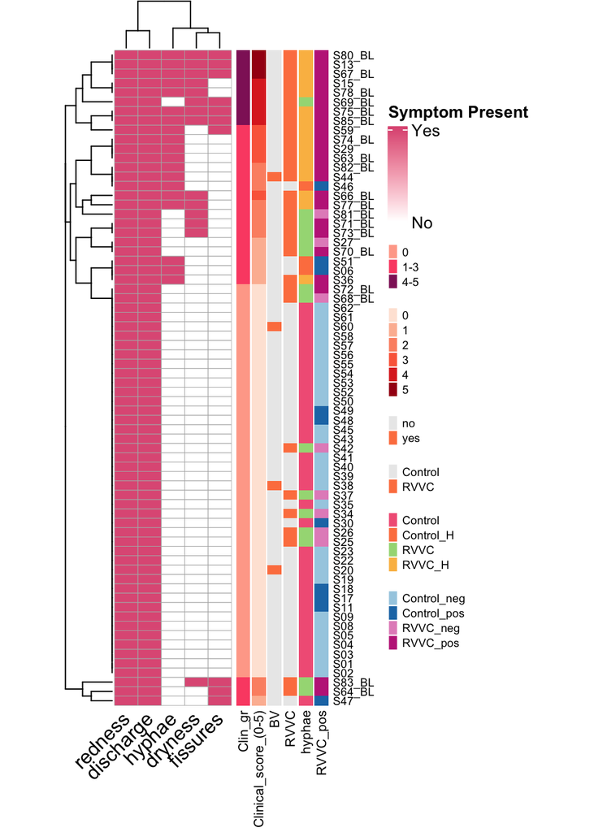

```r
# Create heatmap
H <- Heatmap(
  mat,
  width = unit(ncol(mat) * 5, "mm"),
  height = unit(nrow(mat) * 2, "mm"),
  name = "Symptom Present",
  col = col_fun,
  right_annotation = row_annot,
  #cluster_rows = FALSE,
  #cluster_columns = FALSE,
  row_names_side = "right",
  column_names_rot = 45,
  row_names_gp = gpar(fontsize = 7),
  heatmap_legend_param = list(
    at = c(0, 1),
    labels = c("No", "Yes")
  ),
  #   cell_fun = function(j, i, x, y, width, height, fill) {
  #   grid.rect(x, y, width, height, gp = gpar(col = "grey70", lwd = 0.5, fill = NA))
  # }
  layer_fun = function(j, i, x, y, width, height, fill) {
    # Draw cell borders without overwriting fill
    grid.rect(
      x = x,
      y = y,
      width = width,
      height = height,
      gp = gpar(col = "grey70", lwd = 0.4, fill = NA)
    )
  }
)
draw(H)
```

```r
# group information
annot_col <- meta %>%
  filter(svamp_ID %in% rownames(X$species$TR)) %>%
  # select(-`Age (years)`) %>%
  select(
    1:12,
    metab_louvain,
    microb_louvain,
    fun_louvain,
    CST,
    `Clinical_score_(0-5)`
  ) %>%
  mutate(across(2:8, ~ factor(.x))) %>%
  mutate(
    txt_clin = ifelse(
      grepl("0", .$`Clinical_score_(0-5)`),
      NA,
      as.character(.$`Clinical_score_(0-5)`)
    )
  ) %>%
  mutate(txt_id = ifelse(RVVC == "RVVC", .$svamp_ID, NA))

#### UMAP analysis ####
set.seed(1)
umap_dfs <- map(
  X$strain,
  ~ uwot::umap(
    .x,
    n_neighbors = 10,
    init = "spectral",
    scale = T
  )
) %>%
  map(
    .,
    ~ tibble(
      "UMAP 1" = .x[, 1],
      "UMAP 2" = .x[, 2],
      "ID" = rownames(.x)
    )
  ) %>%
  map(., ~ left_join(., annot_col, by = c("ID" = "svamp_ID")))

#### UMAP plotting by groups ####

# save plot to file
#ggsave(paste0("./Figures/09/", "Bulk_UMAP.png"), p)

UMAP_fun <- function(umap_df, group_var, txt_var, title = "") {
  p <- ggplot(
    umap_df,
    aes(
      x = `UMAP 1`,
      y = `UMAP 2`,
      fill = .data[[group_var]],
      shape = RVVC_pos,
      color = .data[[group_var]]
    )
  ) +
    #geom_jitter( shape=21, size=3, color="white", width=.5, height=.5) +  # Tassos used jitter
    geom_point(size = 3, alpha = 1) +
    scale_colour_manual(
      values = pal[[group_var]],
      name = "",
      aesthetics = c("colour", "fill")
    ) +
    scale_shape_manual(values = c(4, 21, 17, 15), name = "", ) + #specify individual shapes+
    geom_text(
      data = umap_df,
      aes(x = `UMAP 1`, y = `UMAP 2`, label = .data[[txt_var]]),
      size = 3,
      hjust = 0,
      nudge_x = 0.07,
      color = "gray51"
    ) +
    ggtitle(title) +
    theme_bw(base_size = 14) +
    theme(
      line = element_blank(),
      axis.ticks = element_line(color = "black"),
      aspect.ratio = 1,
      axis.title = element_blank()
    )
  return(p)
}
```

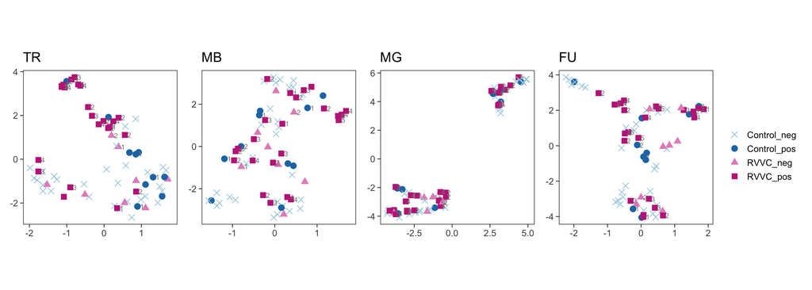

```r
meta_clus <- colnames(annot_col)

# quartz(width = 14, height = 5)
p <- imap(umap_dfs, ~ UMAP_fun(.x, "RVVC_pos", "txt_clin", title = .y))
patchwork::wrap_plots(p, nrow = 1) + patchwork::plot_layout(guides = "collect")
```

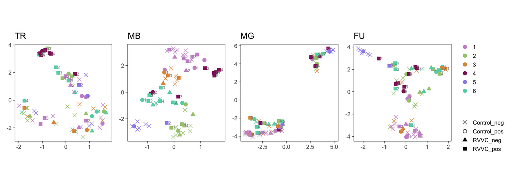

```r
p <- imap(umap_dfs, ~ UMAP_fun(.x, "metab_louvain", "txt_clin", title = .y))
patchwork::wrap_plots(p, nrow = 1) + patchwork::plot_layout(guides = "collect")
```

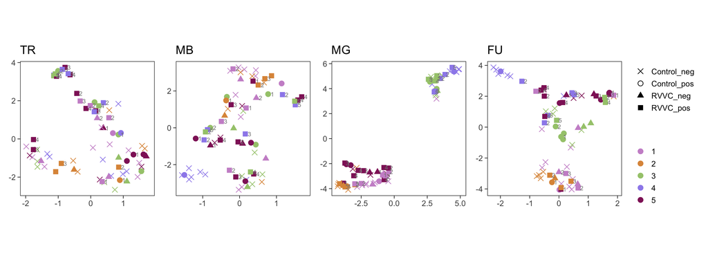

```r
p <- imap(umap_dfs, ~ UMAP_fun(.x, "microb_louvain", "txt_clin", title = .y))
patchwork::wrap_plots(p, nrow = 1) + patchwork::plot_layout(guides = "collect")
```

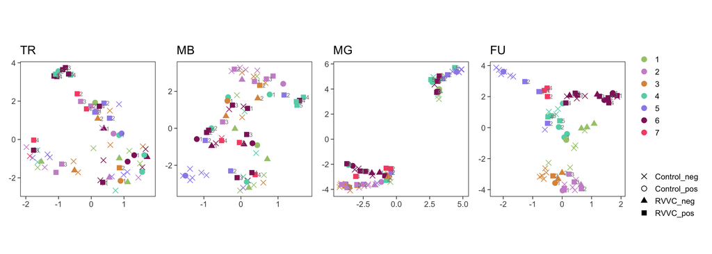

```r
p <- imap(umap_dfs, ~ UMAP_fun(.x, "fun_louvain", "txt_clin", title = .y))
patchwork::wrap_plots(p, nrow = 1) + patchwork::plot_layout(guides = "collect")
```

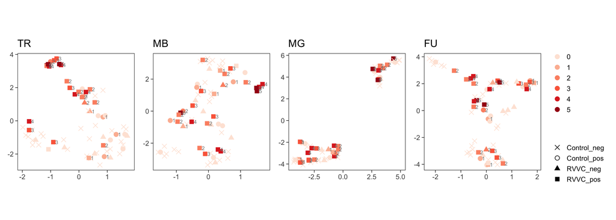

```r
p <- imap(
  umap_dfs,
  ~ UMAP_fun(.x, "Clinical_score_(0-5)", "txt_clin", title = .y)
)
patchwork::wrap_plots(p, nrow = 1) + patchwork::plot_layout(guides = "collect")
```